#Exploratory Analysis of Prosper Loans ### J. Chris Dumville

[Prosper Loan data](https://docs.google.com/document/d/e/2PACX-1vRmVtjQrgEPfE3VoiOrdeZ7vLPO_p3KRdb_o-z6E_YJ65tDOiXkwsDpLFKI3lUxbD6UlYtQHXvwiZKx/pub?embedded=true) provided by Udacity

##Info Prosper.com is a P2P lending marketplace, and this loan data was last updated 03/11/2014. With my history as a fraud analyst, I want to use that lens for this analysis to see if I can determine fields that could be used to mitigate future losses.

## Introductory Analysis

```
## [1] "C:/Users/chris/Desktop/Udacity files/Project 3"
```

Let’s start by checking out the data:

```
##  [1] "ListingKey"                          "ListingNumber"
##  [3] "ListingCreationDate"                 "CreditGrade"
##  [5] "Term"                                "LoanStatus"
##  [7] "ClosedDate"                          "BorrowerAPR"
##  [9] "BorrowerRate"                        "LenderYield"
## [11] "EstimatedEffectiveYield"             "EstimatedLoss"
## [13] "EstimatedReturn"                     "ProsperRating..numeric."
## [15] "ProsperRating..Alpha."               "ProsperScore"
## [17] "ListingCategory..numeric."           "BorrowerState"
## [19] "Occupation"                          "EmploymentStatus"
## [21] "EmploymentStatusDuration"            "IsBorrowerHomeowner"
## [23] "CurrentlyInGroup"                    "GroupKey"
## [25] "DateCreditPulled"                    "CreditScoreRangeLower"
## [27] "CreditScoreRangeUpper"               "FirstRecordedCreditLine"
## [29] "CurrentCreditLines"                  "OpenCreditLines"
```

[output cut: 26 more lines]

```
## 'data.frame':    113937 obs. of  81 variables:
##  $ ListingKey                         : chr  "1021339766868145413AB3B" "10273602499503308B223C1" "0EE9337825851032864889A" "0EF5356002482715299901A" ...
##  $ ListingNumber                      : int  193129 1209647 81716 658116 909464 1074836 750899 768193 1023355 1023355 ...
##  $ ListingCreationDate                : chr  "2007-08-26 19:09:29.263000000" "2014-02-27 08:28:07.900000000" "2007-01-05 15:00:47.090000000" "2012-10-22 11:02:35.010000000" ...
##  $ CreditGrade                        : chr  "C" "" "HR" "" ...
##  $ Term                               : int  36 36 36 36 36 60 36 36 36 36 ...
##  $ LoanStatus                         : chr  "Completed" "Current" "Completed" "Current" ...
##  $ ClosedDate                         : chr  "2009-08-14 00:00:00" "" "2009-12-17 00:00:00" "" ...
##  $ BorrowerAPR                        : num  0.165 0.12 0.283 0.125 0.246 ...
##  $ BorrowerRate                       : num  0.158 0.092 0.275 0.0974 0.2085 ...
##  $ LenderYield                        : num  0.138 0.082 0.24 0.0874 0.1985 ...
##  $ EstimatedEffectiveYield            : num  NA 0.0796 NA 0.0849 0.1832 ...
##  $ EstimatedLoss                      : num  NA 0.0249 NA 0.0249 0.0925 ...
##  $ EstimatedReturn                    : num  NA 0.0547 NA 0.06 0.0907 ...
##  $ ProsperRating..numeric.            : int  NA 6 NA 6 3 5 2 4 7 7 ...
```

[output cut: 67 more lines]

```
## [1] 113937
```

```
## [1] 81
```

Now that we’ve seen what we’re dealing with, we can take a closer look at the data and see what may have value for our purposes.

# Univariate Plots Section

Let’s start with the ProsperScore, as that sounds like it is some sort of proprietary risk score this lender uses to gauge their loans.

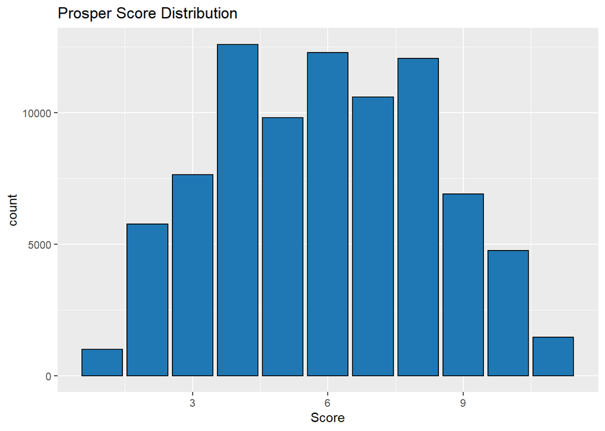

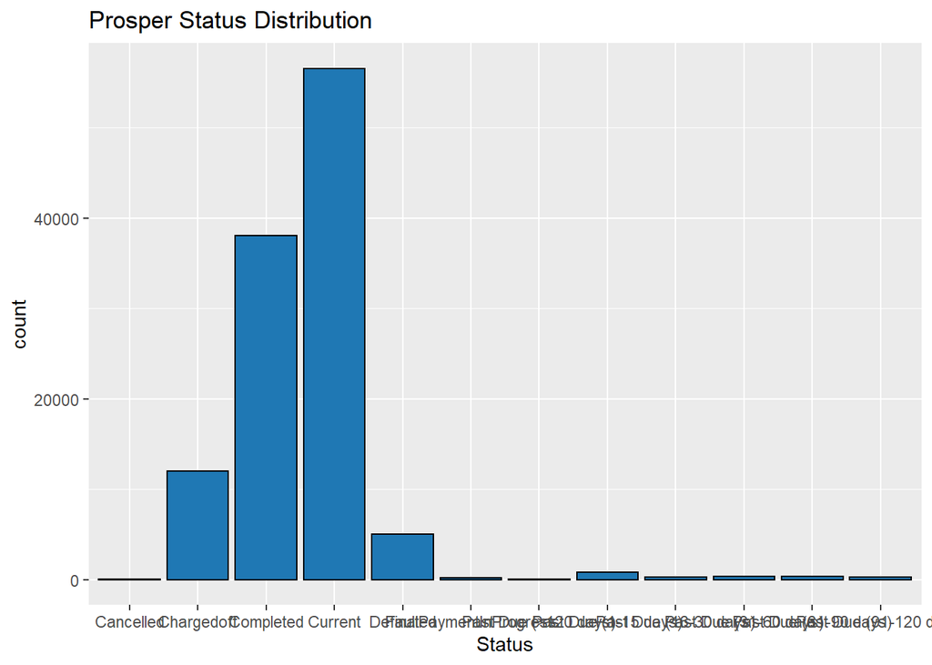

Here we see some interesting numbers, charge-offs, defaults, current and completed. These will give us a high level picture of how much fraud there is but just eyeballing this graph, we see a little more than 10K charge-offs, and nearly 40K completed loans. This is a 20% charge off rate on loans where there is no outstanding risk, but could give us a good indicator of how we’ll we expect this loan portfolio to perform over time if loan issuing guidelines have remained constant.

Next let’s look at the length of these loans.

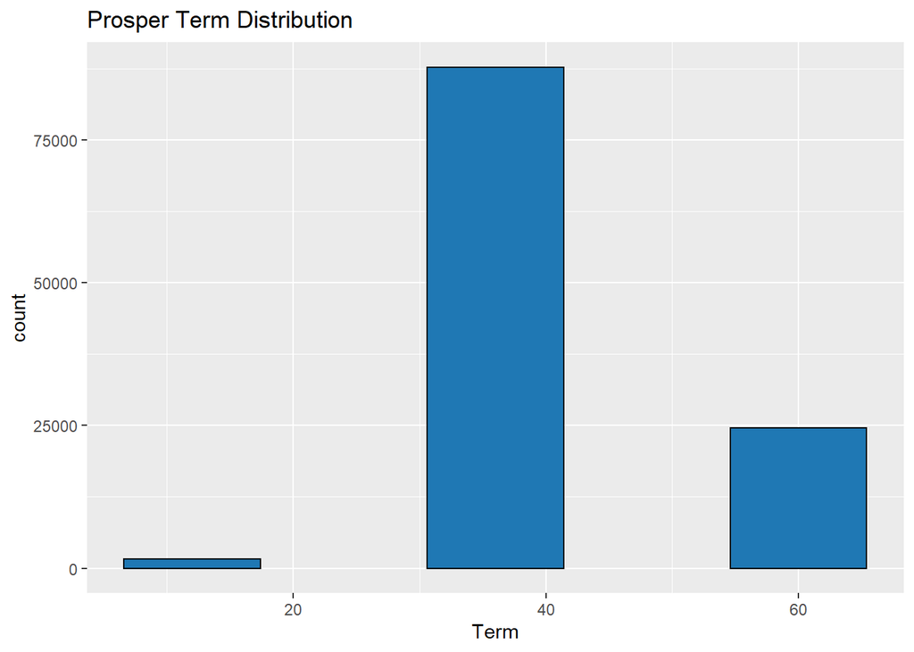

This shows us that most of our data is in the 36 month or 3 year range, with a subset (15-20%) of the loans in the 60 month, or 5 year range. This is good to note for when we dive deeper into the charge offs alone.

Now, let’s take a look at the type of rates that users are paying across these terms.

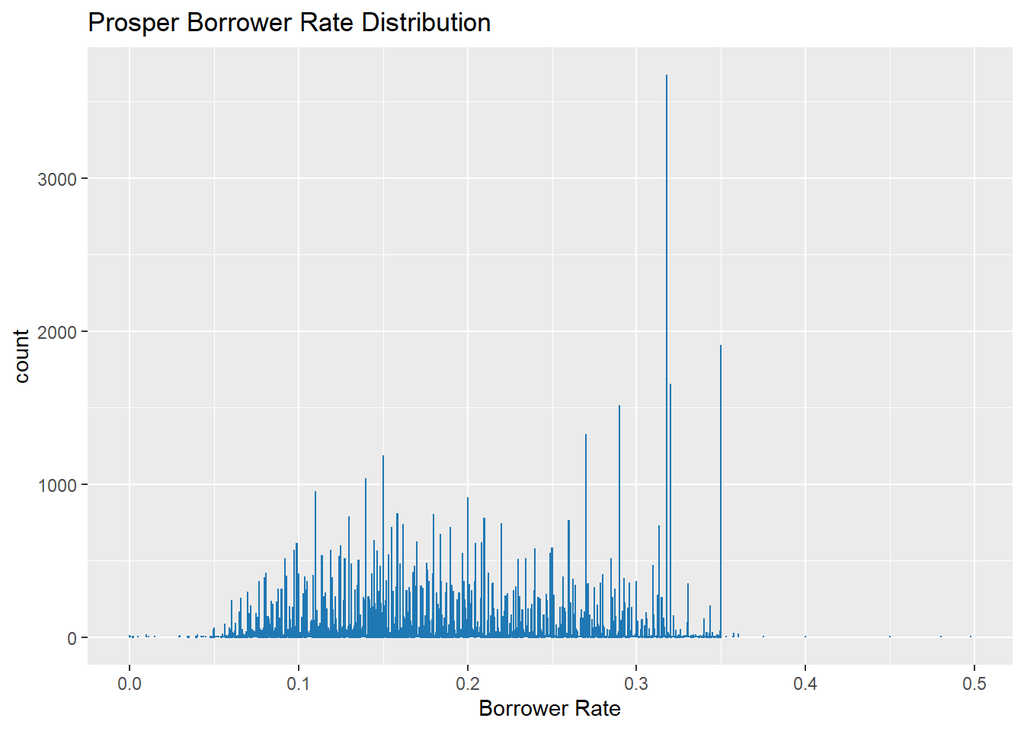

With rates that high, I’d expect to see high yields, so let’s look at that next.

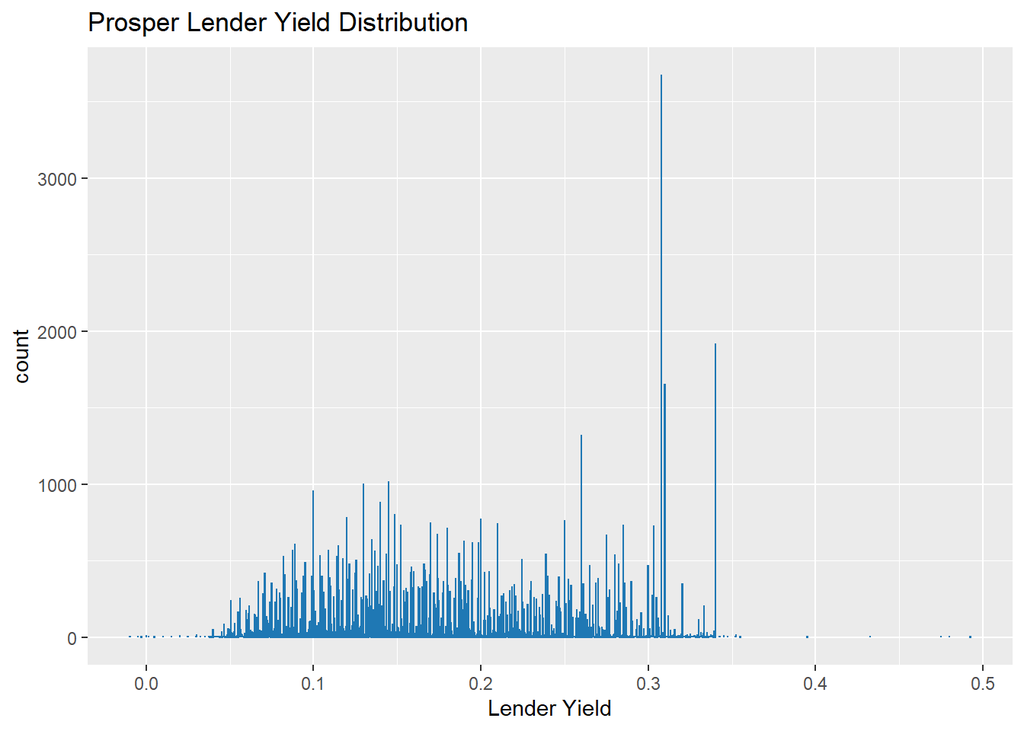

Those yields are very similar to the rates we saw in the last plot, however, the entire distribution is shifted left along the x axis, signifying that yields are similar, but lower than the borrower rate.

Next we look at the Employment Status.

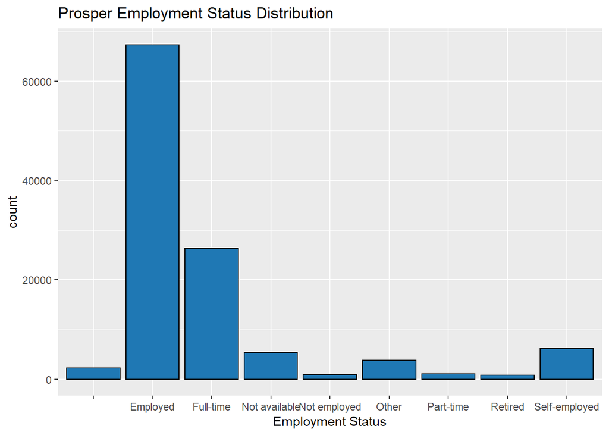

Here we can see that most are employed, nothing out of the ordinary there, one would expect a lender to require a means of repayment, and a job is the primary form for these customers.

If these customers are mostly employed, let’s see some info about their incomes.

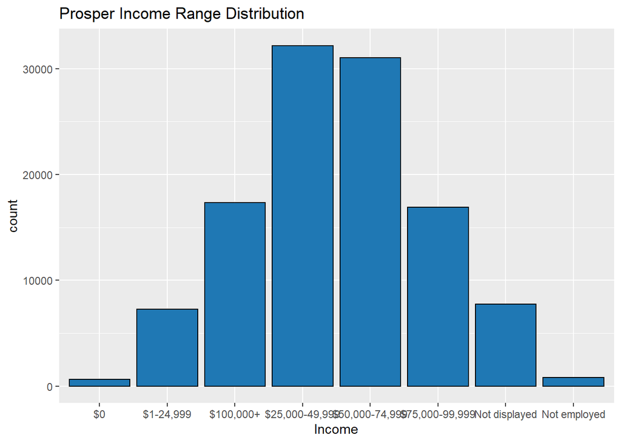

Now let’s take a look at the debt to income ratio and see how that compares among our borrowers.

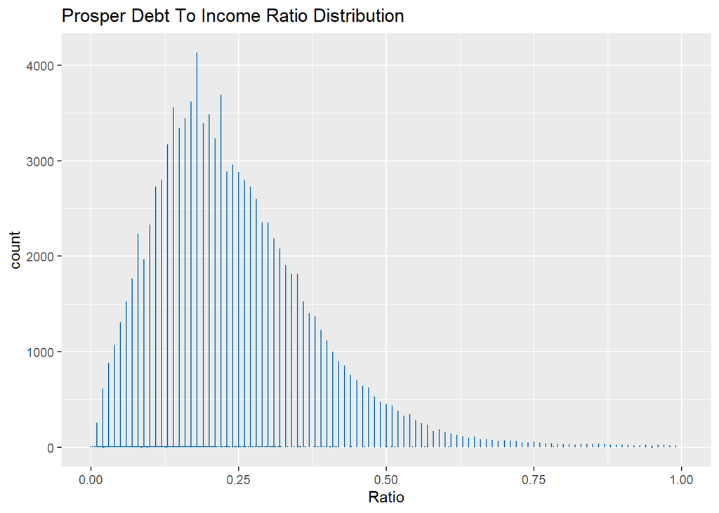

Now let’s look at their credit scores, those should be a good indicator of credit worthiness based on prior history with credit products as tracked by the big 3 credit reporting firms, TransUnion, Experian, and Equifax.

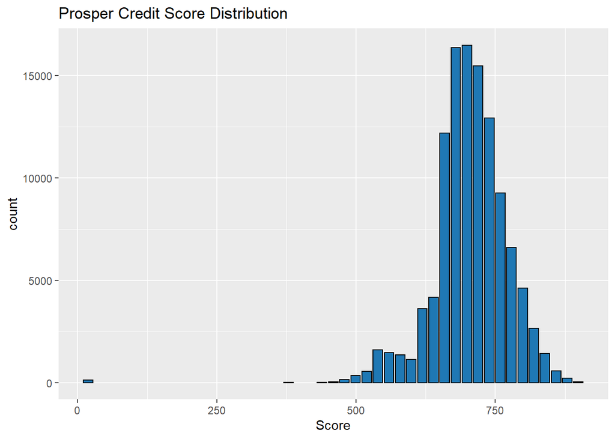

Interesting distribution here, we have mainly higher credit scores, with the mean around the 700 range, and the vast majority falling above 625. This makes sense, we would expect a lender to want to lend to those with a track record of having used credit as expected, I imagine if this data was extended to all applicants rather than simply performed loans, the distribution would shift wildly.

Next let’s see where these loans are from.

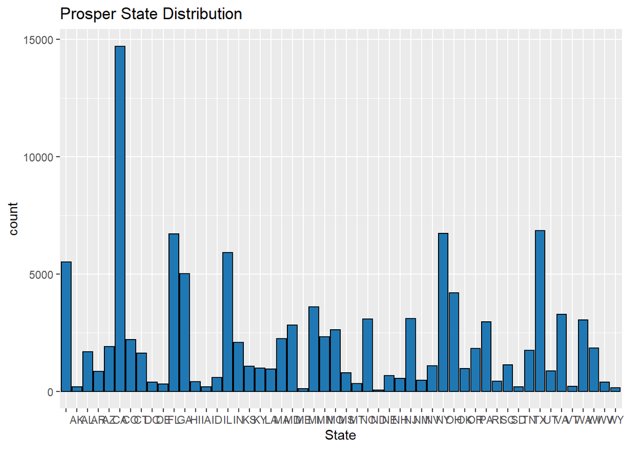

Most loans are from CA, not surprising for a start-up that began in San Francisco, but there are loans from nearly all states, with a handful having more than 5000, and many others around the 2500 level.

Next let’s take a look at whether or not the borrowers are homeowners.

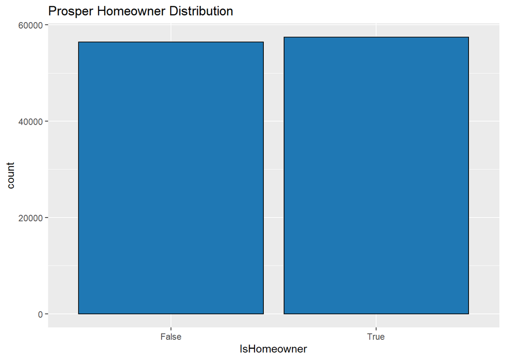

Looks like our borrowers are very evenly split when it comes to whether or not they own a home.

Before we start getting into the bivariate portion of the analysis, let’s look at one last visual, the number of loans over time. First we must change our date into a date format, then let’s print the range of that field to see our time-frame.

```r
# Formatting dates
prosper$ListingCreationDate <- prosper$ListingCreationDate %>%
  as.Date(format = '%Y-%m-%d')
prosper$LoanOriginationDate <- prosper$LoanOriginationDate %>%
  as.Date(format = '%Y-%m-%d')
prosper$Year <- as.numeric(format(prosper$LoanOriginationDate,'%Y'))
range(prosper$ListingCreationDate)
```

```
## [1] "2005-11-09" "2014-03-10"
```

```r
range(prosper$Year)
```

```
## [1] 2005 2014
```

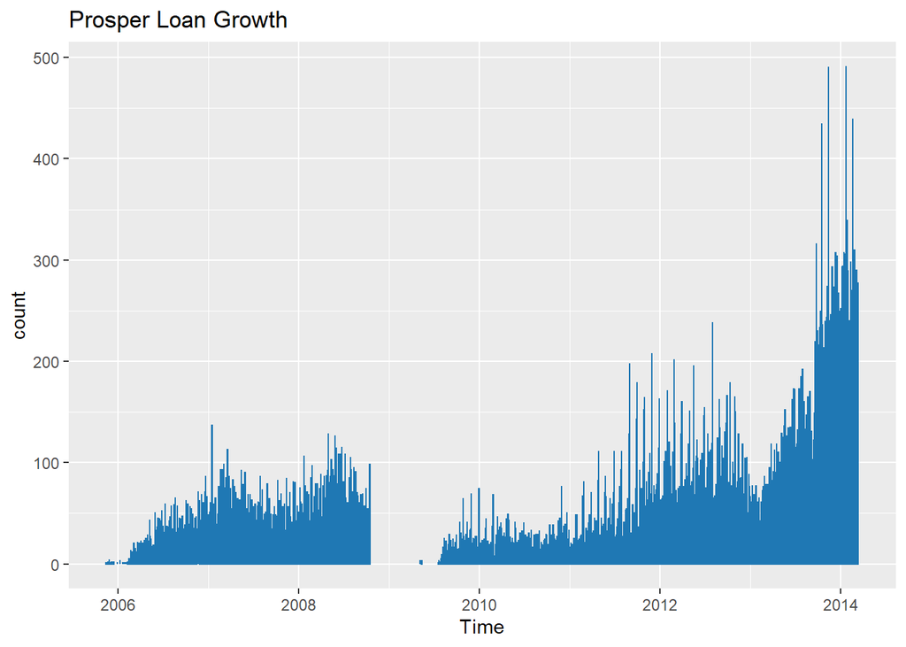

Interesting plot here, we see that the volume has been increasing recently, which is a good sign for the company overall. The other interesting thing here is the volume in 2009, this led me to a Google search that led to articles about a SEC relaunch for their IPO which resulted in the temporary halt in new loan originations.

# Bivariate Plots Section

Now let’s dive into the bivariate portion of the analysis. Here, we can start to drill down into the charge-offs compared to completed loans across other fields.

A good place to start is with the Prosper Score. A good risk score should identify the charge off loans at a higher frequency than good loans.

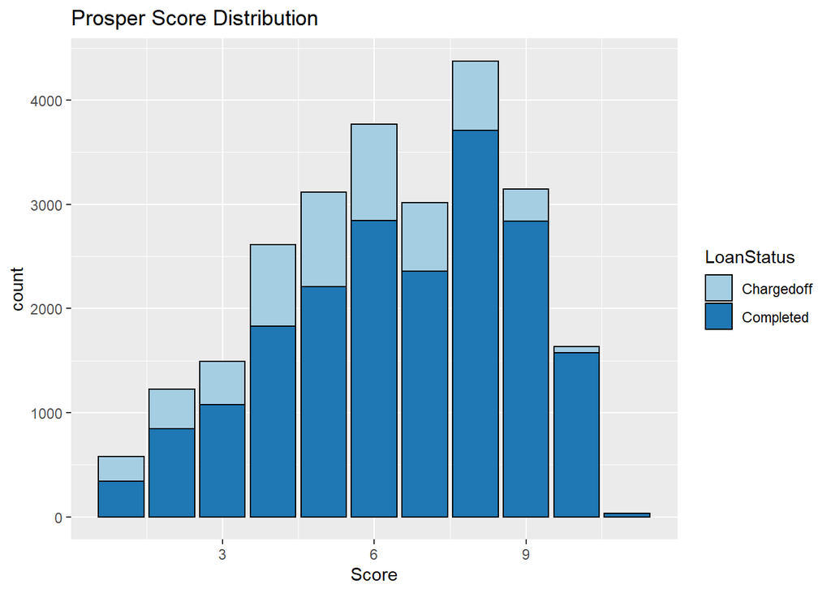

Very interesting graph here, this illustrates the difficulties in detecting fraud. Based on these scores, it looks like the higher the number, the lower the risk. At 9+, we have around 500 charged-off, whereas we have nearly 3 times that number for the other end of the distribution. The interesting part of this graph is that the majority of the charged-off loans happen in the most common risk scores 4-8, this means the fraud tends to follow the trends of typical borrowers, which hinders detection and leads to increased charged-off loans.

Let’s take a look at the number of charge-offs vs completed by year, this will tell us if Prosper is seeing growth or reduction in their charged-off rates.

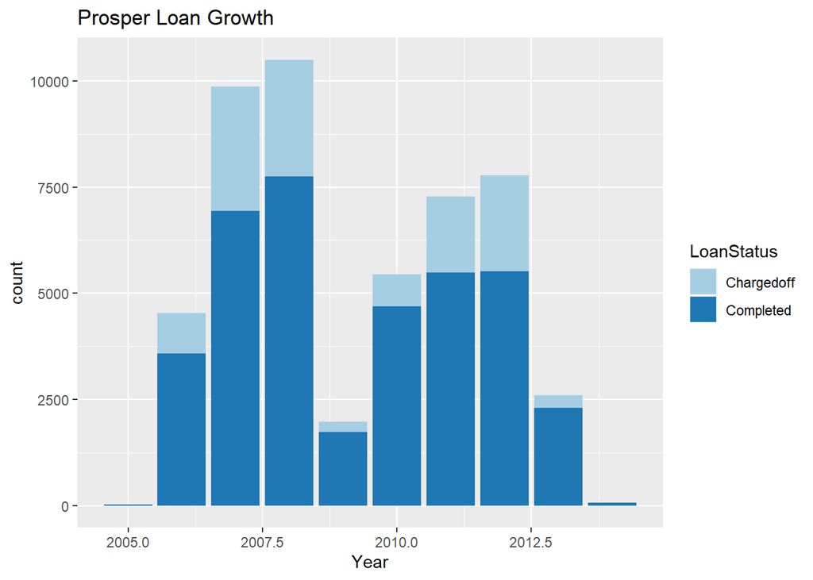

Here we can see that Prosper initially struggled with their charge-back rates in first few years until their temporary halt due to the SEC in 2009. In 2010-2012 the volume normalized, but charge-backs increased yearly.

Let’s keep going through a few more variables to see if there is anything that seems to be a good charge-back indicator. Loan term is a good one to check next.

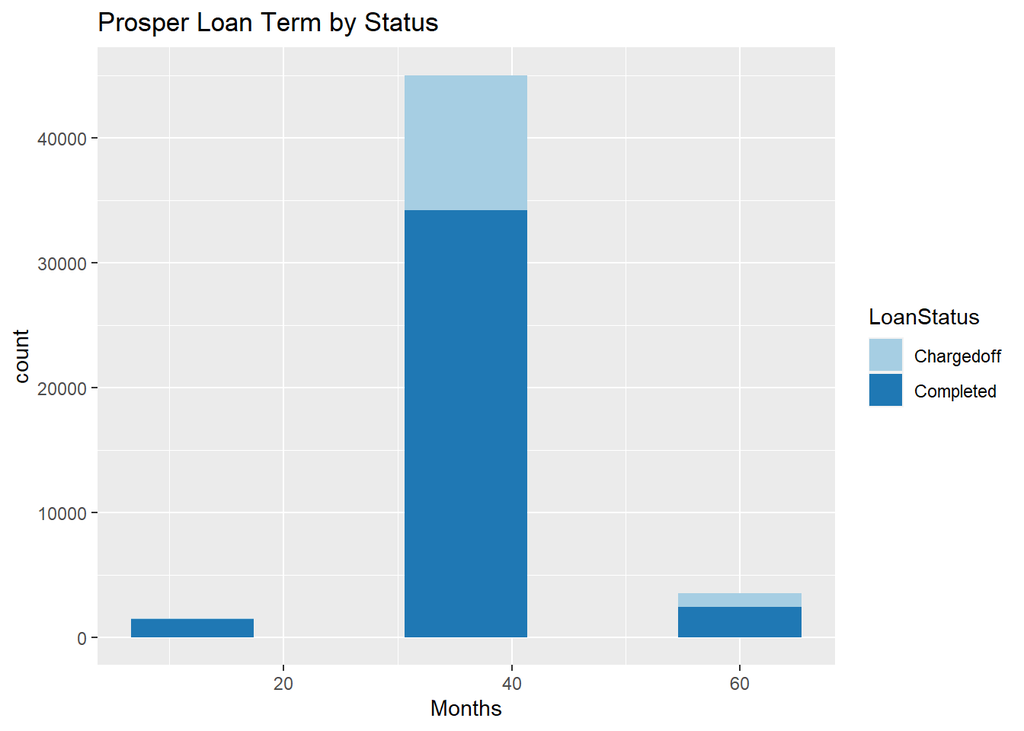

By volume, we see rates we would expect, short term has very few charge-backs and very little volume, and the most popular term has the most charge-backs.

Maybe we will see something more insightful by home ownership

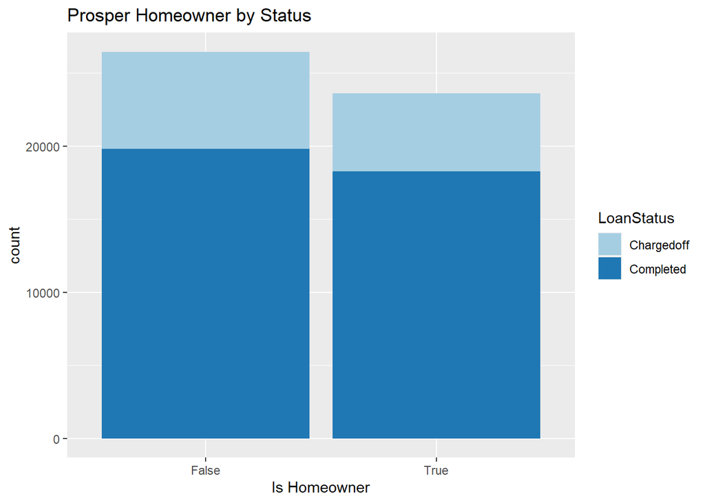

This field is also split pretty evenly as our overall portfolio is, however it appears there is a slightly higher rate of charge-backs for borrowers that are not homeowners.

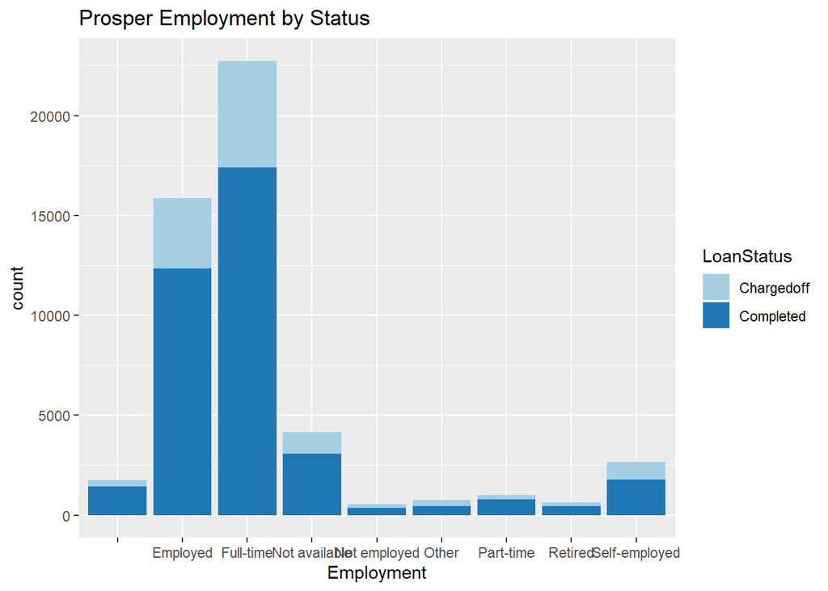

Once again we see the majority of the charge-backs in our most populated fields employed and full-time. However, there appears to also be a higher rate among the self employed and not available.

Area for further analysis: Fields where one can isolate a higher rate of charge-backs can be analyzed with further granularity to determine business rules for risk mitigation. For example, we may want to look at the Prosper scores for not available and self employed to see if a limit on score could be set for those customers to mitigate investor risk.

Next up we can look at income range.

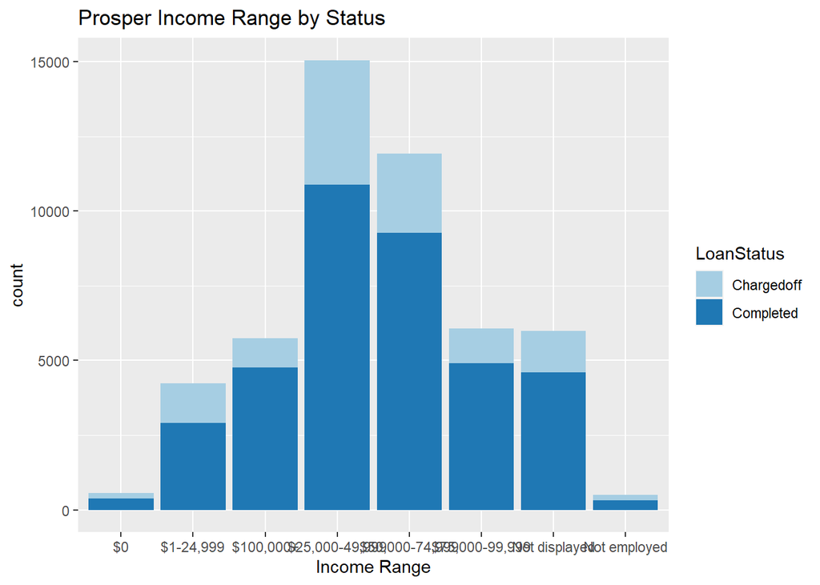

The charge-offs here look pretty well distributed, with higher ranges for higher volume values, but nothing that warrants further investigation.

Next up we can look at credit score.

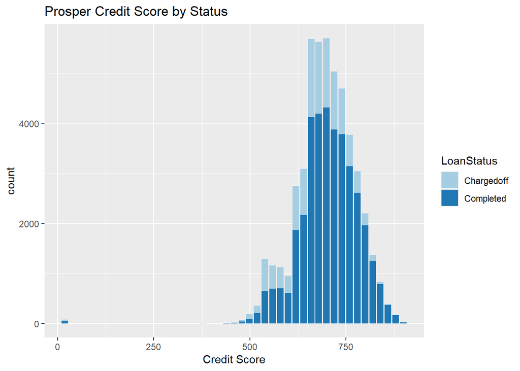

This is interesting, our volume is higher where we see more legitimate activity, but as the scores get lower, the charge-off rate appears to increase. Those lower credit scores could present an opportunity to reduce rates by focusing on similarities among that subset.

Last one I want to check on is state, to see if there is a geographic component to the charge-offs. Based on on prior plot, I would expect to see most in CA.

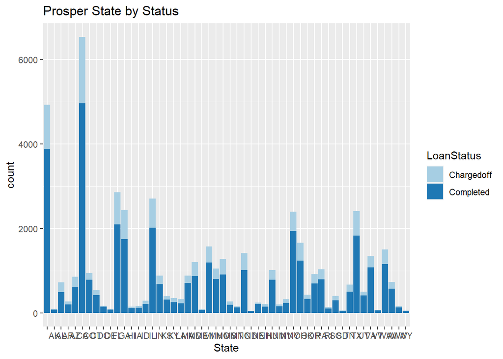

Here we see that CA does in fact have the most charge-offs, but some of the smaller volume states that still have high rates could be further investigated.

# Final Plots:

## Plot 1

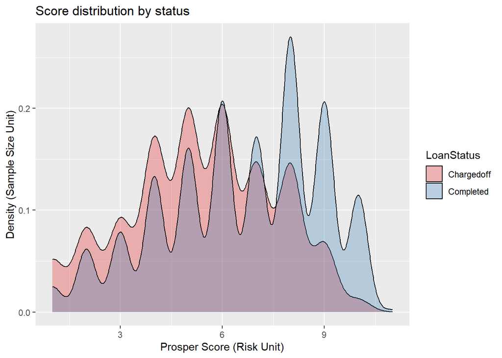

## Plot 2

[figure not shown]

## Plot 3

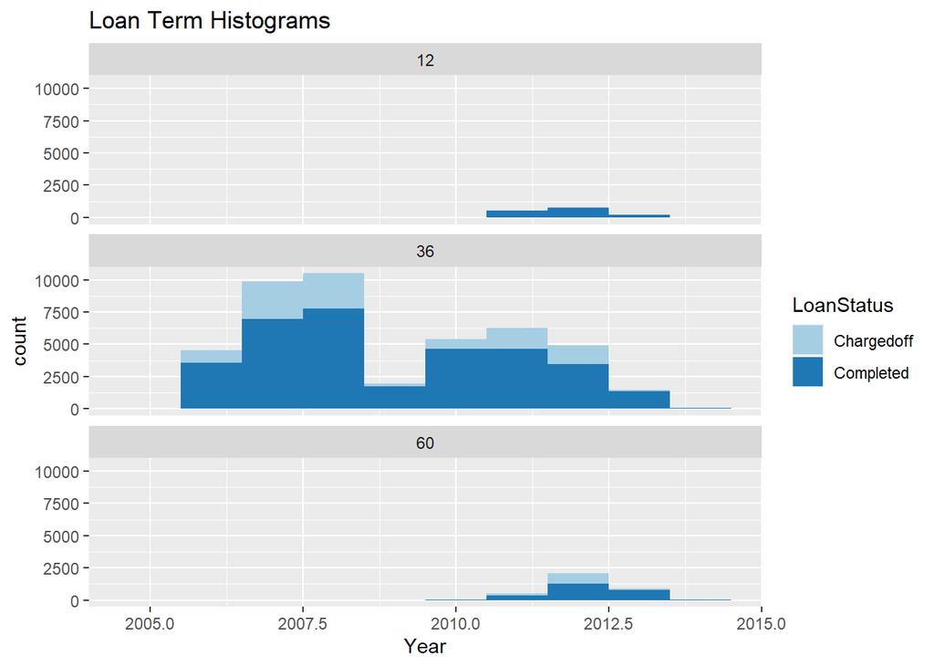

# Summary:

#### Plot 1

Plot 1 is of the density of the Prosper Scores by Loan Status. At our lower risk loans (right), we see higher densities of good loans vs charged-off loans, whereas the further we move to the left, we see that the density changes and our charged-off loans have a higher density. This graph illustrates the difficulty in trying to detect which loans will be completed vs those that will be charged-off and will end up being a loss to investors as there is significant overlap.

#### Plot 2

Plot 2 is a scatter plot of Debt to Income vs Prosper score, with the different colors representing the Loan Status. This plot represents opportunity for additional charge-offs to be caught, as there are trends such as higher DTIs and particular Prosper scores that could be exploited in the application process to reject these loans before they are funded, thus stopping potential losses across future loans.

#### Plot 3

Plot 3 is a histogram for the different loan term lengths. I split the bar graph to show charge-off loans vs completed loans. This graph shows us the trends among the different loans and where focus on risk mitigation efforts should go. 36 month will always deserve attention, as it is the highest volume of loans, however the 60 month stand out as they have been offered for only a smaller amount of time, yet still have a high charge-off rate, which means they may be an attractive target, as longer terms would generally yield larger loans and thus may be an area that would require attention.

# Reflections:

#### Where did I run into difficulties in the analysis?

I ran into difficulties in this analysis with the lack of detail in the data, there are other metrics, measures, and data points that could lead to a much more fascinating and substantial analysis of this data, but what I was able to surmise was interesting and insightful.

#### Where did I find successes?

I found success in looking for fraud and risk patterns among this data set even though there was no clear cut indicator or detils from the application aside to determine ways to capture some of this risk via analysis.

#### How could the analysis be enriched in future work (e.g. additional data and analyses)?

With additional data, or further granularization of the data could continue to point to other insights or trends that could be acted upon by Prosper if they are so incentivized.